# Assignment2_Ans

STAT380

2023-10-29

```r
###
library(tree)
###
library(ISLR)
#attach(Carseats)
library(rattle)
```

```r
library(rpart.plot)
library(RColorBrewer)
library(partykit)
```

The data set `Carseats’ is a simulated data set containing sales of child car seats at 400 different stores of a specific departmental store over a period of a few months. For the different activities in this assignment, we consider a categorical binary variable, that we call ‘High_Sales’. We consider the sales amount is high, i.e., High_Sales=1, if the number of car sets that are sold is greater than 8 in the particular store.

# Problem A

### A2. Add the new variable to the dataset `Carseats’.

```r
data(Carseats)
### A1.
High_Sales<-ifelse(Carseats$Sales>8, 'High', 'Low')

### A2.
Carseats$High_Sales=as.factor(High_Sales)
```

### A3. Build a classification tree where the response is ‘High_Sales’ and the predictors are all the other variables except ‘Sales’ and ‘High_Sales’.

```r
names(Carseats)
```

```
##  [1] "Sales"       "CompPrice"   "Income"      "Advertising" "Population"
##  [6] "Price"       "ShelveLoc"   "Age"         "Education"   "Urban"
## [11] "US"          "High_Sales"
```

```r
### A3.
fit = rpart(High_Sales~CompPrice+Income+Advertising+Population+Price+ShelveLoc+Age+Education+Urban+US,data=Carseats,method="class",minsplit=20,cp=-1)
```

### A4.1 Plot the fitted tree and

#### A4.2 describe the different classification region.

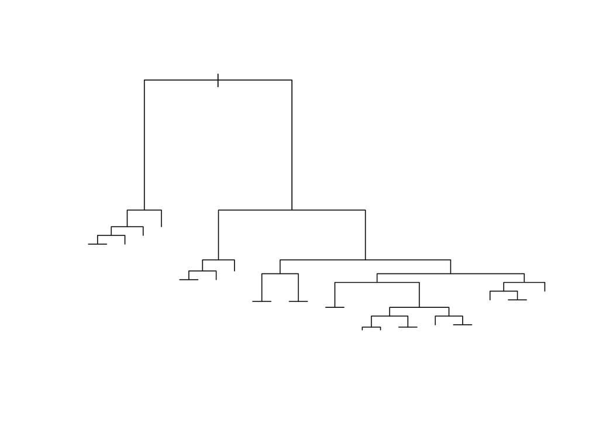

```r
# A4.1 Plot the regression tree
plot(fit)
```

[figure not shown]

```r
plot(as.party(fit)) # Basic Plot
```

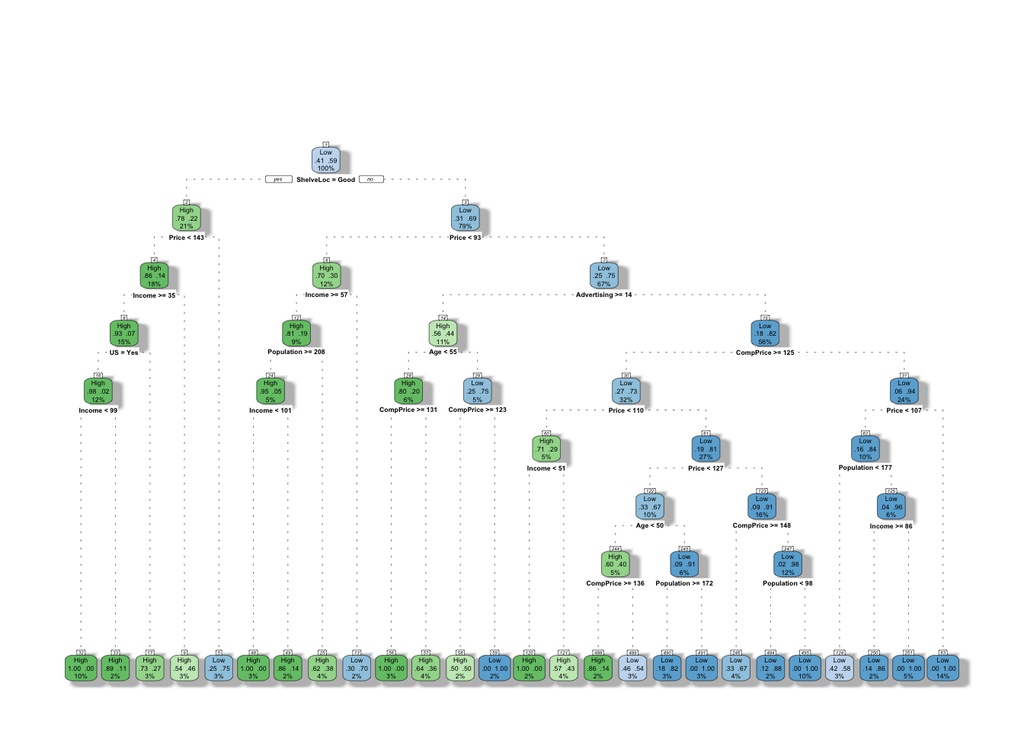

```r
fancyRpartPlot(fit, caption = NULL) # More Nicer plot but need libraries `RColorBrewer', `rattle' and `rpart.plot'
```

```r
#A4.2 describe the different classification region.
```

## Training and Testing Set

### A5.1. Now, Create a training set and a testing set , use a training set (70% in the training Set and 30% in test set).

```r
#### A5.1:
set.seed(234)
 #inTrain = createDataPartition(Carseats$Sales, p = 0.75, list = FALSE)
  Total_data_size=as.integer(nrow(Carseats))
  inTrain = sample(1:Total_data_size, round(Total_data_size*.70))
  Training_Set = Carseats[inTrain, ]
  dim(Training_Set)
```

```
## [1] 280  12
```

```r
  Testing_Set<-Carseats[-inTrain, ]
  dim(Testing_Set)
```

```
## [1] 120  12
```

### A5.2. Fit the Classification Tree in the Training set and Plot the tree

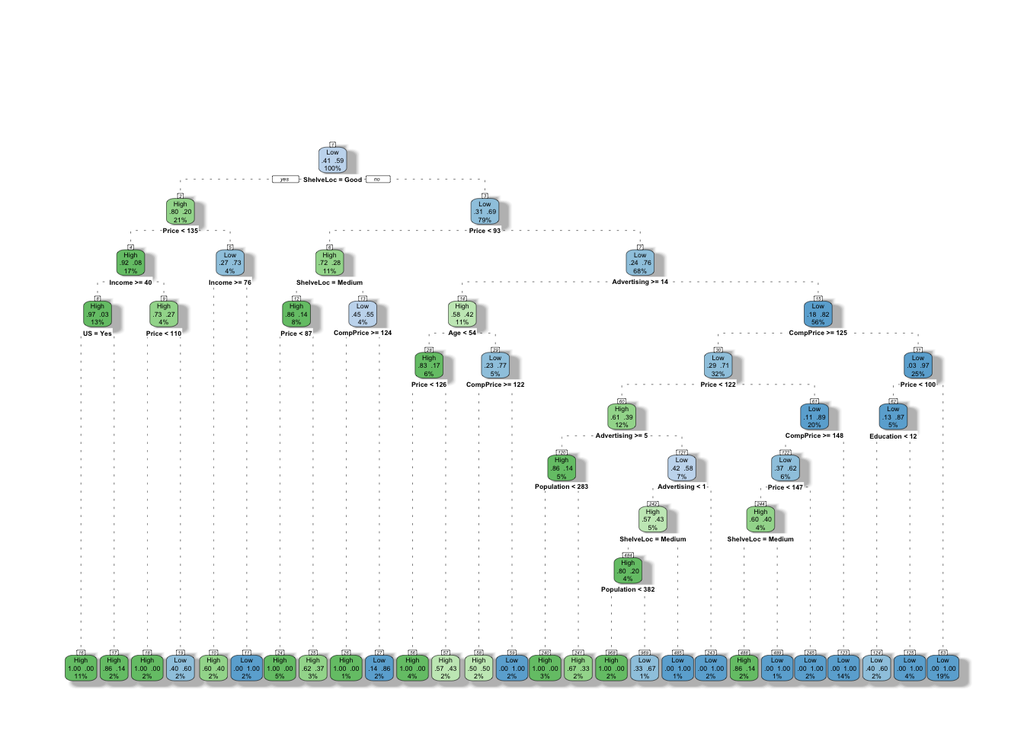

```r
### A5.2.
fit_train = rpart(High_Sales~CompPrice+Income+Advertising+Population+Price+ShelveLoc+Age+Education+Urban+US,data=Training_Set,method="class",minsplit=10,cp=-1)



# plot mytree
fancyRpartPlot(fit_train, caption = NULL)
```

### A6. Comment on the Error Rate in the validation part.

Identify an optimal value for complexiety parameter `cp’. Note: cp = “value” is an assigned numeric value that will determine how tall a tree is to be growen. The smaller value (closer to 0) leads to the larger the trees. The default value is 0.01.

```r
summary(fit_train)
```

```
## Call:
## rpart(formula = High_Sales ~ CompPrice + Income + Advertising +
##     Population + Price + ShelveLoc + Age + Education + Urban +
##     US, data = Training_Set, method = "class", minsplit = 10,
##     cp = -1)
##   n= 280
##
##              CP nsplit rel error    xerror       xstd
## 1   0.301724138      0 1.0000000 1.0000000 0.07105815
## 2   0.120689655      1 0.6982759 0.6982759 0.06540818
## 3   0.051724138      2 0.5775862 0.6465517 0.06388083
## 4   0.043103448      4 0.4741379 0.6206897 0.06304649
## 5   0.030172414      5 0.4310345 0.6034483 0.06246283
## 6   0.025862069      7 0.3706897 0.5862069 0.06185651
## 7   0.021551724     10 0.2931034 0.5775862 0.06154463
## 8   0.014367816     12 0.2500000 0.5517241 0.06057311
## 9   0.008620690     15 0.2068966 0.5603448 0.06090303
## 10  0.004310345     17 0.1896552 0.5862069 0.06185651
## 11  0.000000000     19 0.1810345 0.5862069 0.06185651
## 12 -1.000000000     26 0.1810345 0.5862069 0.06185651
##
## Variable importance
##       Price   ShelveLoc   CompPrice Advertising         Age      Income
##          27          18          15          12           8           7
##  Population   Education          US       Urban
##           7           4           1           1
##
## Node number 1: 280 observations,    complexity param=0.3017241
##   predicted class=Low   expected loss=0.4142857  P(node) =1
##     class counts:   116   164
##    probabilities: 0.414 0.586
##   left son=2 (59 obs) right son=3 (221 obs)
##   Primary splits:
##       ShelveLoc   splits as  RLR,       improve=21.853040, (0 missing)
##       Price       < 92.5  to the left,  improve=15.953800, (0 missing)
##       Income      < 60.5  to the right, improve=10.590280, (0 missing)
##       Advertising < 7.5   to the right, improve=10.046180, (0 missing)
##       Age         < 61.5  to the left,  improve= 4.865515, (0 missing)
##
## Node number 2: 59 observations,    complexity param=0.04310345
```

[output cut: 375 more lines]

[output not shown]

```r
printcp(fit_train)
```

```
##
## Classification tree:
## rpart(formula = High_Sales ~ CompPrice + Income + Advertising +
##     Population + Price + ShelveLoc + Age + Education + Urban +
##     US, data = Training_Set, method = "class", minsplit = 10,
##     cp = -1)
##
## Variables actually used in tree construction:
## [1] Advertising Age         CompPrice   Education   Income      Population
## [7] Price       ShelveLoc   US
##
## Root node error: 116/280 = 0.41429
##
## n= 280
##
##            CP nsplit rel error  xerror     xstd
## 1   0.3017241      0   1.00000 1.00000 0.071058
## 2   0.1206897      1   0.69828 0.69828 0.065408
## 3   0.0517241      2   0.57759 0.64655 0.063881
## 4   0.0431034      4   0.47414 0.62069 0.063046
## 5   0.0301724      5   0.43103 0.60345 0.062463
## 6   0.0258621      7   0.37069 0.58621 0.061857
## 7   0.0215517     10   0.29310 0.57759 0.061545
## 8   0.0143678     12   0.25000 0.55172 0.060573
## 9   0.0086207     15   0.20690 0.56034 0.060903
## 10  0.0043103     17   0.18966 0.58621 0.061857
## 11  0.0000000     19   0.18103 0.58621 0.061857
## 12 -1.0000000     26   0.18103 0.58621 0.061857
```

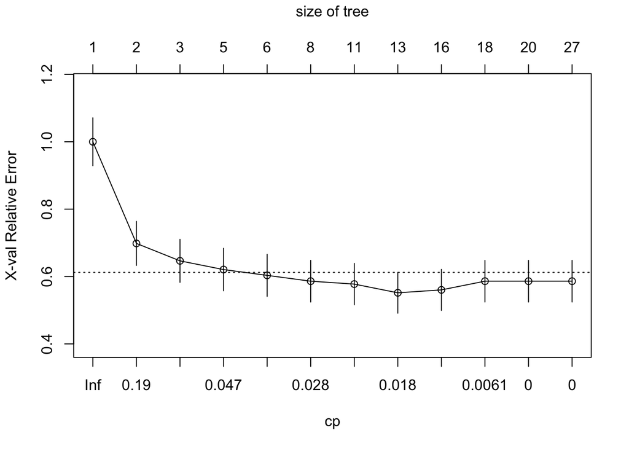

```r
plotcp(fit_train)
```

### A7. Prune the tree According to the optimal value of cp that you have obtainied in A6.

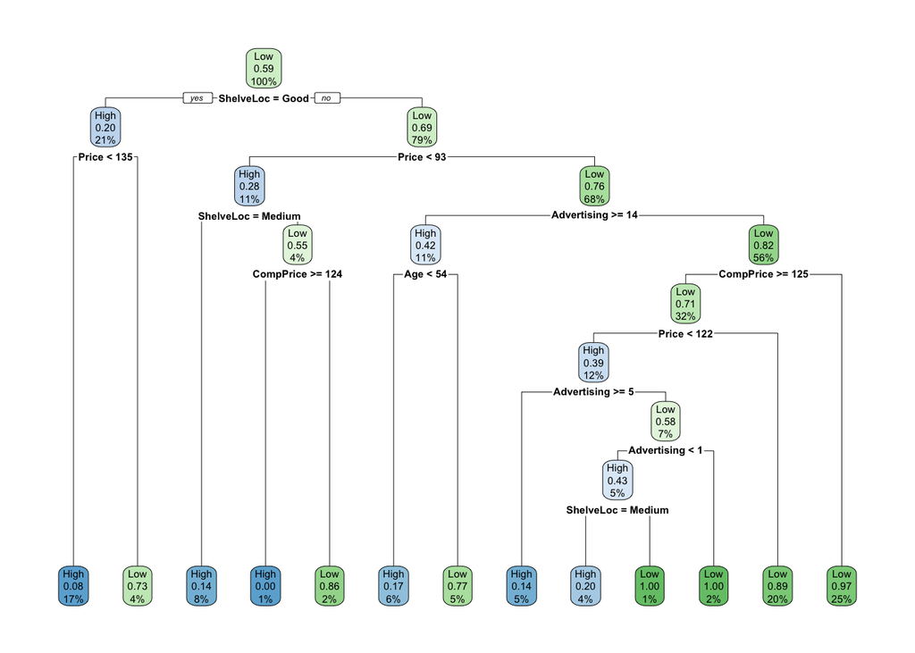

```r
### A8.

bestcp <-fit_train$cptable[which.min(fit_train$cptable[,"xerror"]),"CP"]
pruned.tree <- prune(fit_train, cp = bestcp)
rpart.plot(pruned.tree)
```

###

### A8.1 Predict on the Testing set with the pruned tree and

### A8.2 Predict on the Testing set with the pruned tree andPredict on the Testing set with the entire tree fitted using the training set

```r
### A8.1
# Alternate specification
pred_test.prune = predict(pruned.tree, Testing_Set, type="class")

### A8.1
pred_test.full_tree=predict(fit_train, Testing_Set, type="class")
```

### A9.1 Create A classification Tables of the errors using the Predicted values from the pruned tree

### A9.2 Create A classification Tables of the errors using the Predicted values from entire tree fitted using the training set

### A10. Compare the classification performance of the tree and the pruned tree.

```r
#A9.1
table(pred_test.prune,Testing_Set$High_Sales )
```

```
##
## pred_test.prune High Low
##            High   31  14
##            Low    17  58
```

```r
#A9.2
table(pred_test.full_tree,Testing_Set$High_Sales )
```

```
##
## pred_test.full_tree High Low
##                High   34  15
##                Low    14  57
```

```r
## Write a Conslusion of your finding
```

[output not shown]

# Problem B (Fitting Regression Trees)

### We will use the regression trees for the Boston Housing data

Load the data from the github course page using: BostonH<-read.csv(url(“https://raw.githubusercontent.com/subhadippal2019/STAT380UAEU/main/BostonHousing.csv”))

```r
BostonH<-read.csv(url("https://raw.githubusercontent.com/subhadippal2019/STAT380UAEU/main/BostonHousing.csv"))
```

### B1 Split the data in Training and Testing Set. use a 60%/40% split fopr the trainig and Testing

```r
#### A5.1:
set.seed(234)
 #inTrain = createDataPartition(Carseats$Sales, p = 0.6, list = FALSE)
  Total_data_size=as.integer(nrow(BostonH))
  inTrain = sample(1:Total_data_size, round(Total_data_size*.60))
  Training_Set = BostonH[inTrain, ]
  dim(Training_Set)
```

```
## [1] 304  14
```

```r
  Testing_Set<-BostonH[-inTrain, ]
  dim(Testing_Set)
```

```
## [1] 202  14
```

```r
  names(BostonH)
```

```
##  [1] "CRIM"      "ZN"        "INDUS"     "CHAS"      "NOX"       "RM"
##  [7] "AGE"       "DIS"       "RAD"       "TAX"       "PTRATIO"   "LSTAT"
## [13] "MEDV"      "CAT..MEDV"
```

### B2.

Fit a regression tree on the Training Set using the `MEDV', the median price of houses in a region, as the response variable while all the other variables EXCEPT the`CAT..MEDV’ as the covariates. Display/plot the fitted tree.

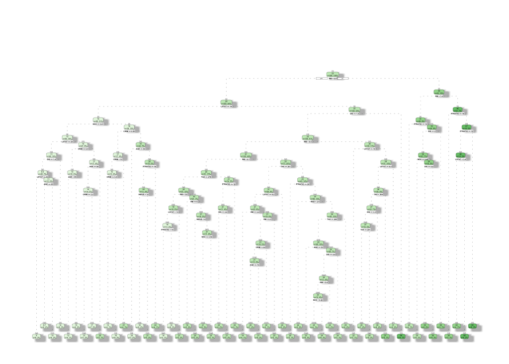

```r
reg_fit_train = rpart(MEDV~CRIM+ZN+INDUS+CHAS+NOX+RM+AGE+DIS+RAD+TAX+PTRATIO+LSTAT,data=Training_Set,method="anova",minsplit=10,cp=-1)

# plot fitted tree
fancyRpartPlot(reg_fit_train, caption = NULL)
```

### B3. Comment on the Error Rate in the validation part.

Identify an optimal value for complexiety parameter `cp’.

```r
summary(reg_fit_train)
```

```
## Call:
## rpart(formula = MEDV ~ CRIM + ZN + INDUS + CHAS + NOX + RM +
##     AGE + DIS + RAD + TAX + PTRATIO + LSTAT, data = Training_Set,
##     method = "anova", minsplit = 10, cp = -1)
##   n= 304
##
##               CP nsplit  rel error    xerror       xstd
## 1   4.694095e-01      0 1.00000000 1.0116921 0.10837895
## 2   1.462492e-01      1 0.53059055 0.7084272 0.08551202
## 3   1.003575e-01      2 0.38434131 0.5627995 0.07072420
## 4   6.912512e-02      3 0.28398383 0.4936381 0.06499579
## 5   4.108818e-02      4 0.21485871 0.4014709 0.06044461
## 6   2.135148e-02      5 0.17377053 0.3527239 0.05726232
## 7   2.121130e-02      6 0.15241905 0.3478926 0.05864717
## 8   1.199707e-02      7 0.13120775 0.3141176 0.05768518
## 9   6.738840e-03      8 0.11921068 0.2668952 0.04835341
## 10  6.523295e-03      9 0.11247184 0.2462870 0.04721017
## 11  4.392687e-03     10 0.10594855 0.2557983 0.04923260
## 12  3.613822e-03     11 0.10155586 0.2557230 0.04922291
## 13  3.268399e-03     13 0.09432821 0.2636671 0.04971929
## 14  3.220896e-03     14 0.09105981 0.2620812 0.04968381
## 15  3.182450e-03     15 0.08783892 0.2690708 0.05006567
## 16  2.472982e-03     17 0.08147402 0.2606376 0.04965900
## 17  2.345312e-03     18 0.07900104 0.2647593 0.04990972
## 18  2.031008e-03     19 0.07665572 0.2650563 0.05033385
## 19  1.833160e-03     20 0.07462472 0.2617809 0.05030700
## 20  1.763265e-03     21 0.07279156 0.2634976 0.05051524
## 21  1.524593e-03     22 0.07102829 0.2621032 0.05045542
## 22  1.456666e-03     24 0.06797910 0.2619675 0.05044618
## 23  1.380497e-03     25 0.06652244 0.2615355 0.05045238
## 24  1.334825e-03     26 0.06514194 0.2612389 0.05044247
## 25  1.240845e-03     27 0.06380712 0.2531459 0.04615447
## 26  1.183344e-03     28 0.06256627 0.2528892 0.04613778
## 27  1.149371e-03     30 0.06019958 0.2526916 0.04607407
## 28  1.101504e-03     31 0.05905021 0.2533379 0.04609731
## 29  1.024189e-03     33 0.05684720 0.2544382 0.04611685
## 30  9.805197e-04     34 0.05582301 0.2562454 0.04613944
## 31  8.357757e-04     35 0.05484249 0.2568518 0.04614560
## 32  7.468992e-04     36 0.05400672 0.2550853 0.04571234
## 33  7.291792e-04     37 0.05325982 0.2556557 0.04570651
```

[output cut: 983 more lines]

[output not shown]

```r
printcp(reg_fit_train)
```

```
##
## Regression tree:
## rpart(formula = MEDV ~ CRIM + ZN + INDUS + CHAS + NOX + RM +
##     AGE + DIS + RAD + TAX + PTRATIO + LSTAT, data = Training_Set,
##     method = "anova", minsplit = 10, cp = -1)
##
## Variables actually used in tree construction:
##  [1] AGE     CRIM    DIS     INDUS   LSTAT   NOX     PTRATIO RAD     RM
## [10] TAX
##
## Root node error: 26326/304 = 86.599
##
## n= 304
##
##             CP nsplit rel error  xerror     xstd
```

[output cut: 49 more lines]

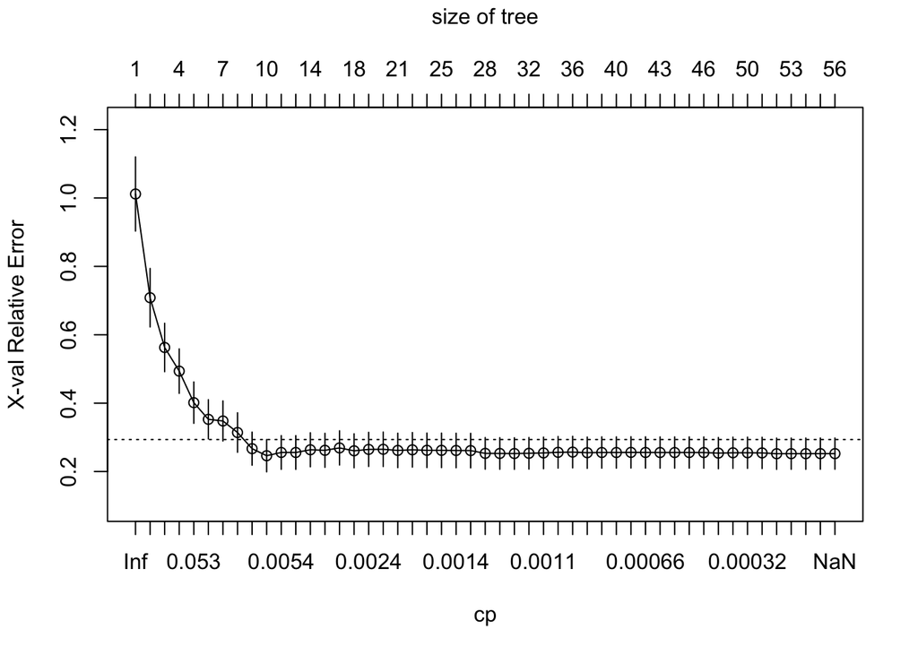

```r
plotcp(reg_fit_train)
```

## B4. Prune the regression tree to find the optimal number of nodes.

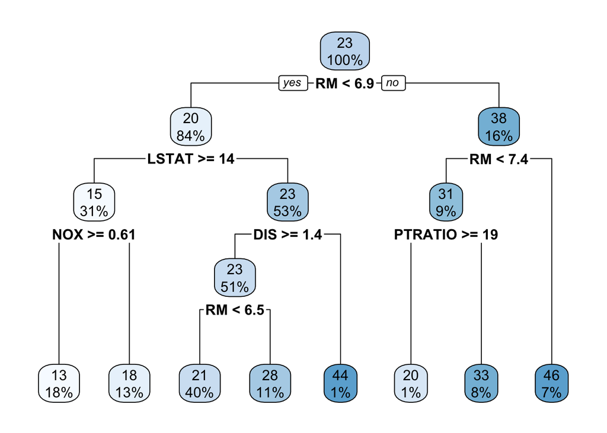

```r
bestcp <-fit_train$cptable[which.min(fit_train$cptable[,"xerror"]),"CP"]
reg_pruned.tree <- prune(reg_fit_train, cp = bestcp)
rpart.plot(reg_pruned.tree)
```

###

## B5.1 Predict on the Testing set with the pruned tree. Plot the predicted values vs the response values in the test set.

## B5.2 Predict on the Testing set with the Entire tree fitted to the training set. Plot the predicted values vs the response values in the test set.

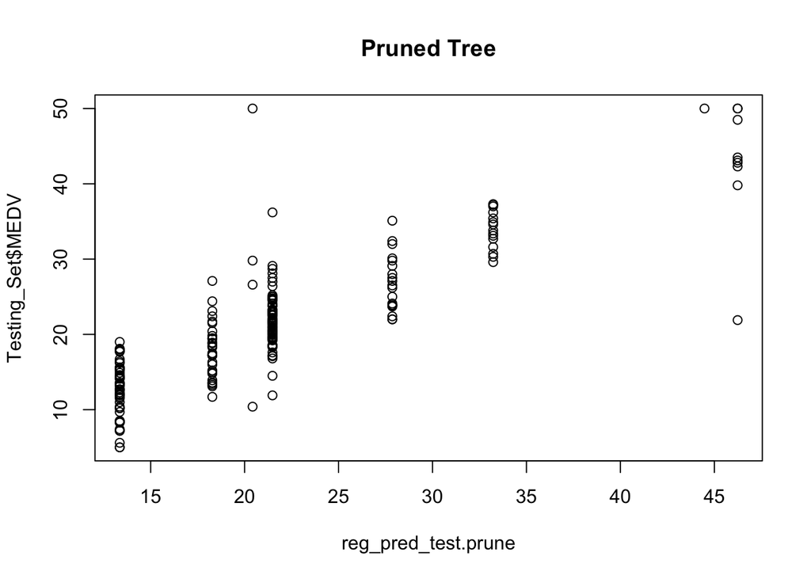

```r
### B5.1
# Alternate specification
reg_pred_test.prune = predict(reg_pruned.tree, Testing_Set)
plot(reg_pred_test.prune,Testing_Set$MEDV, main="Pruned Tree" )
```

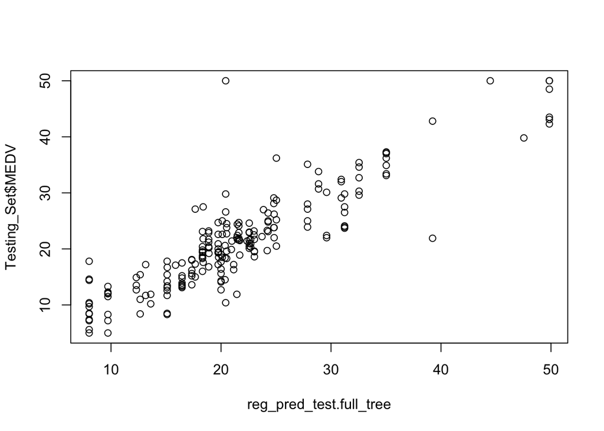

```r
### B5.2
reg_pred_test.full_tree=predict(reg_fit_train, Testing_Set, main="Entire Tree on Trainig Set")
plot(reg_pred_test.full_tree,Testing_Set$MEDV )
```

###

### B6 calculate the MSE for both the prediction and compare their MSE. Comment on your finding.

```r
##
mean((reg_pred_test.prune  -Testing_Set$MEDV )^2)
```

```
## [1] 20.98047
```

```r
mean((reg_pred_test.full_tree-Testing_Set$MEDV )^2)
```

```
## [1] 18.55217
```